# Risk Factor Analysis

## Outcome Variable

**Outcome Variable:** pers_wast

## Predictor Variables

**Intervention Variable:** feducyrs

**Adjustment Set:**

unadjusted

## Stratifying Variables

The analysis was stratified on these variable(s):

- agecat
- studyid
- country

## Data Summary

| agecat | studyid | country | feducyrs | pers_wast | n_cell | n |
| --- | --- | --- | --- | --- | --- | --- |
| 0-24 months | COHORTS | GUATEMALA | High | 0 | 182 | 999 |
| 0-24 months | COHORTS | GUATEMALA | High | 1 | 6 | 999 |
| 0-24 months | COHORTS | GUATEMALA | Low | 0 | 431 | 999 |
| 0-24 months | COHORTS | GUATEMALA | Low | 1 | 14 | 999 |
| 0-24 months | COHORTS | GUATEMALA | Medium | 0 | 351 | 999 |
| 0-24 months | COHORTS | GUATEMALA | Medium | 1 | 15 | 999 |
| 0-24 months | COHORTS | INDIA | High | 0 | 454 | 1242 |
| 0-24 months | COHORTS | INDIA | High | 1 | 33 | 1242 |
| 0-24 months | COHORTS | INDIA | Low | 0 | 366 | 1242 |
| 0-24 months | COHORTS | INDIA | Low | 1 | 38 | 1242 |
| 0-24 months | COHORTS | INDIA | Medium | 0 | 324 | 1242 |
| 0-24 months | COHORTS | INDIA | Medium | 1 | 27 | 1242 |
| 0-24 months | COHORTS | PHILIPPINES | High | 0 | 892 | 2659 |
| 0-24 months | COHORTS | PHILIPPINES | High | 1 | 31 | 2659 |
| 0-24 months | COHORTS | PHILIPPINES | Low | 0 | 736 | 2659 |
| 0-24 months | COHORTS | PHILIPPINES | Low | 1 | 44 | 2659 |
| 0-24 months | COHORTS | PHILIPPINES | Medium | 0 | 897 | 2659 |
| 0-24 months | COHORTS | PHILIPPINES | Medium | 1 | 59 | 2659 |
| 0-24 months | GMS-Nepal | NEPAL | High | 0 | 126 | 596 |
| 0-24 months | GMS-Nepal | NEPAL | High | 1 | 20 | 596 |
| 0-24 months | GMS-Nepal | NEPAL | Low | 0 | 221 | 596 |
| 0-24 months | GMS-Nepal | NEPAL | Low | 1 | 36 | 596 |
| 0-24 months | GMS-Nepal | NEPAL | Medium | 0 | 169 | 596 |
| 0-24 months | GMS-Nepal | NEPAL | Medium | 1 | 24 | 596 |
| 0-24 months | JiVitA-3 | BANGLADESH | High | 0 | 3853 | 15189 |
| 0-24 months | JiVitA-3 | BANGLADESH | High | 1 | 178 | 15189 |
| 0-24 months | JiVitA-3 | BANGLADESH | Low | 0 | 5568 | 15189 |
| 0-24 months | JiVitA-3 | BANGLADESH | Low | 1 | 367 | 15189 |
| 0-24 months | JiVitA-3 | BANGLADESH | Medium | 0 | 4914 | 15189 |
| 0-24 months | JiVitA-3 | BANGLADESH | Medium | 1 | 309 | 15189 |

[output cut: 294 more lines]

The following strata were considered:

- agecat: 0-24 months, studyid: COHORTS, country: GUATEMALA
- agecat: 0-24 months, studyid: COHORTS, country: INDIA
- agecat: 0-24 months, studyid: COHORTS, country: PHILIPPINES
- agecat: 0-24 months, studyid: GMS-Nepal, country: NEPAL
- agecat: 0-24 months, studyid: JiVitA-3, country: BANGLADESH
- agecat: 0-24 months, studyid: JiVitA-4, country: BANGLADESH
- agecat: 0-24 months, studyid: LCNI-5, country: MALAWI
- agecat: 0-24 months, studyid: MAL-ED, country: BANGLADESH
- agecat: 0-24 months, studyid: MAL-ED, country: INDIA
- agecat: 0-24 months, studyid: MAL-ED, country: NEPAL
- agecat: 0-24 months, studyid: MAL-ED, country: PERU
- agecat: 0-24 months, studyid: MAL-ED, country: SOUTH AFRICA
- agecat: 0-24 months, studyid: MAL-ED, country: TANZANIA, UNITED REPUBLIC OF
- agecat: 0-24 months, studyid: NIH-Crypto, country: BANGLADESH
- agecat: 0-24 months, studyid: PROBIT, country: BELARUS
- agecat: 0-24 months, studyid: PROVIDE, country: BANGLADESH
- agecat: 0-24 months, studyid: SAS-CompFeed, country: INDIA
- agecat: 0-24 months, studyid: SAS-FoodSuppl, country: INDIA
- agecat: 0-24 months, studyid: TanzaniaChild2, country: TANZANIA, UNITED REPUBLIC OF
- agecat: 0-24 months, studyid: ZVITAMBO, country: ZIMBABWE
- agecat: 0-6 months, studyid: COHORTS, country: PHILIPPINES
- agecat: 0-6 months, studyid: GMS-Nepal, country: NEPAL
- agecat: 0-6 months, studyid: JiVitA-3, country: BANGLADESH
- agecat: 0-6 months, studyid: MAL-ED, country: BANGLADESH
- agecat: 0-6 months, studyid: MAL-ED, country: INDIA
- agecat: 0-6 months, studyid: MAL-ED, country: NEPAL
- agecat: 0-6 months, studyid: MAL-ED, country: PERU
- agecat: 0-6 months, studyid: MAL-ED, country: SOUTH AFRICA
- agecat: 0-6 months, studyid: MAL-ED, country: TANZANIA, UNITED REPUBLIC OF
- agecat: 0-6 months, studyid: NIH-Crypto, country: BANGLADESH
- agecat: 0-6 months, studyid: PROBIT, country: BELARUS
- agecat: 0-6 months, studyid: PROVIDE, country: BANGLADESH
- agecat: 0-6 months, studyid: TanzaniaChild2, country: TANZANIA, UNITED REPUBLIC OF
- agecat: 0-6 months, studyid: ZVITAMBO, country: ZIMBABWE
- agecat: 6-24 months, studyid: COHORTS, country: GUATEMALA
- agecat: 6-24 months, studyid: COHORTS, country: INDIA
- agecat: 6-24 months, studyid: COHORTS, country: PHILIPPINES
- agecat: 6-24 months, studyid: GMS-Nepal, country: NEPAL
- agecat: 6-24 months, studyid: JiVitA-3, country: BANGLADESH
- agecat: 6-24 months, studyid: JiVitA-4, country: BANGLADESH
- agecat: 6-24 months, studyid: LCNI-5, country: MALAWI
- agecat: 6-24 months, studyid: MAL-ED, country: BANGLADESH
- agecat: 6-24 months, studyid: MAL-ED, country: INDIA
- agecat: 6-24 months, studyid: MAL-ED, country: NEPAL
- agecat: 6-24 months, studyid: MAL-ED, country: PERU
- agecat: 6-24 months, studyid: MAL-ED, country: SOUTH AFRICA
- agecat: 6-24 months, studyid: MAL-ED, country: TANZANIA, UNITED REPUBLIC OF
- agecat: 6-24 months, studyid: NIH-Crypto, country: BANGLADESH
- agecat: 6-24 months, studyid: PROBIT, country: BELARUS
- agecat: 6-24 months, studyid: PROVIDE, country: BANGLADESH
- agecat: 6-24 months, studyid: SAS-CompFeed, country: INDIA
- agecat: 6-24 months, studyid: SAS-FoodSuppl, country: INDIA
- agecat: 6-24 months, studyid: TanzaniaChild2, country: TANZANIA, UNITED REPUBLIC OF
- agecat: 6-24 months, studyid: ZVITAMBO, country: ZIMBABWE

### Dropped Strata

Some strata were dropped due to rare outcomes:

- agecat: 0-24 months, studyid: LCNI-5, country: MALAWI
- agecat: 0-24 months, studyid: MAL-ED, country: BANGLADESH
- agecat: 0-24 months, studyid: MAL-ED, country: INDIA
- agecat: 0-24 months, studyid: MAL-ED, country: NEPAL
- agecat: 0-24 months, studyid: MAL-ED, country: PERU
- agecat: 0-24 months, studyid: MAL-ED, country: SOUTH AFRICA
- agecat: 0-24 months, studyid: MAL-ED, country: TANZANIA, UNITED REPUBLIC OF
- agecat: 0-24 months, studyid: NIH-Crypto, country: BANGLADESH
- agecat: 0-24 months, studyid: PROVIDE, country: BANGLADESH
- agecat: 0-6 months, studyid: JiVitA-3, country: BANGLADESH
- agecat: 0-6 months, studyid: MAL-ED, country: BANGLADESH
- agecat: 0-6 months, studyid: MAL-ED, country: INDIA
- agecat: 0-6 months, studyid: MAL-ED, country: NEPAL
- agecat: 0-6 months, studyid: MAL-ED, country: PERU
- agecat: 0-6 months, studyid: MAL-ED, country: SOUTH AFRICA
- agecat: 0-6 months, studyid: MAL-ED, country: TANZANIA, UNITED REPUBLIC OF
- agecat: 0-6 months, studyid: NIH-Crypto, country: BANGLADESH
- agecat: 0-6 months, studyid: PROVIDE, country: BANGLADESH
- agecat: 0-6 months, studyid: ZVITAMBO, country: ZIMBABWE
- agecat: 6-24 months, studyid: LCNI-5, country: MALAWI
- agecat: 6-24 months, studyid: MAL-ED, country: BANGLADESH
- agecat: 6-24 months, studyid: MAL-ED, country: INDIA
- agecat: 6-24 months, studyid: MAL-ED, country: NEPAL
- agecat: 6-24 months, studyid: MAL-ED, country: PERU
- agecat: 6-24 months, studyid: MAL-ED, country: SOUTH AFRICA
- agecat: 6-24 months, studyid: MAL-ED, country: TANZANIA, UNITED REPUBLIC OF
- agecat: 6-24 months, studyid: NIH-Crypto, country: BANGLADESH
- agecat: 6-24 months, studyid: PROVIDE, country: BANGLADESH

## Methods Detail

We’re interested in the causal parameters $E[Y_a]$ for all values of $a \in \mathcal{A}$. These parameters represent the mean outcome if, possibly contrary to fact, we intervened to set all units to have $A=a$. Under the randomization and positivity assumptions, these are identified by the statistical parameters $\psi_a=E_W[E_{Y|A,W}(Y|A=a,W)]$. In addition, we’re interested in the mean of $Y$, $E[Y]$ under no intervention (the observed mean). We will estimate these parameters by using SuperLearner to fit the relevant likelihood factors – $E_{Y|A,W}(Y|A=a,W)$ and $p(A=a|W)$, and then updating our likelihood fit using a joint TMLE.

For unadjusted analyses ($W=\{\}$), initial likelihoods were estimated using Lrnr_glm to estimate the simple $E(Y|A)$ and Lrnr_mean to estimate $p(A)$. For adjusted analyses, a small library containing Lrnr_glmnet, Lrnr_xgboost, and Lrnr_mean was used.

Having estimated these parameters, we will then use the delta method to estimate relative risks and attributable risks relative to a prespecified baseline level of $A$.

# Results Detail

## Results Plots

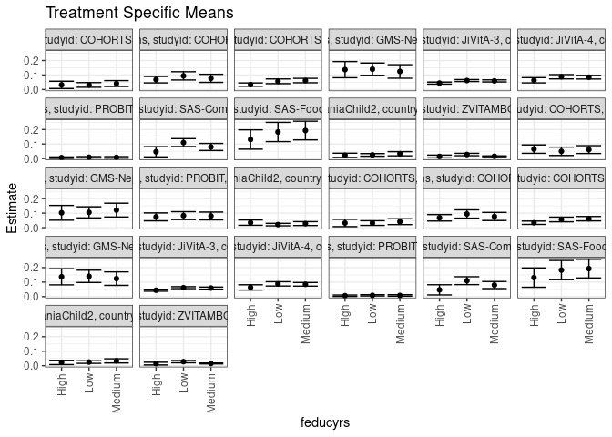

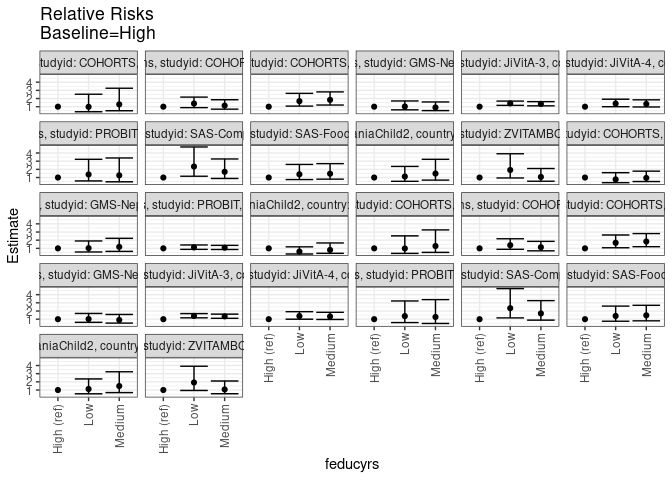

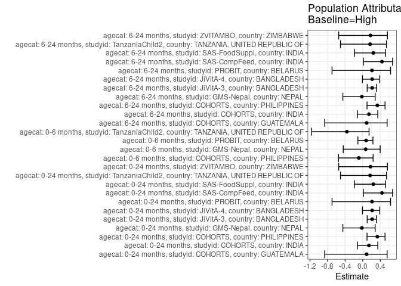

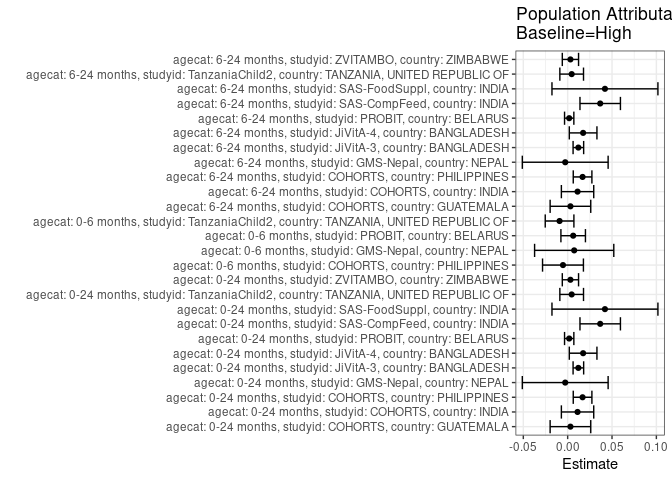

## Results Table

### Parameter: TSM

| agecat | studyid | country | intervention_level | baseline_level | estimate | ci_lower | ci_upper |
| --- | --- | --- | --- | --- | --- | --- | --- |
| 0-24 months | COHORTS | GUATEMALA | High | NA | 0.0319149 | 0.0067764 | 0.0570534 |
| 0-24 months | COHORTS | GUATEMALA | Low | NA | 0.0314607 | 0.0152340 | 0.0476873 |
| 0-24 months | COHORTS | GUATEMALA | Medium | NA | 0.0409836 | 0.0206627 | 0.0613045 |
| 0-24 months | COHORTS | INDIA | High | NA | 0.0677618 | 0.0454305 | 0.0900931 |
| 0-24 months | COHORTS | INDIA | Low | NA | 0.0940594 | 0.0655831 | 0.1225357 |
| 0-24 months | COHORTS | INDIA | Medium | NA | 0.0769231 | 0.0490351 | 0.1048110 |
| 0-24 months | COHORTS | PHILIPPINES | High | NA | 0.0335861 | 0.0219612 | 0.0452111 |
| 0-24 months | COHORTS | PHILIPPINES | Low | NA | 0.0564103 | 0.0402163 | 0.0726042 |
| 0-24 months | COHORTS | PHILIPPINES | Medium | NA | 0.0617155 | 0.0464586 | 0.0769723 |
| 0-24 months | GMS-Nepal | NEPAL | High | NA | 0.1369863 | 0.0811671 | 0.1928055 |
| 0-24 months | GMS-Nepal | NEPAL | Low | NA | 0.1400778 | 0.0976100 | 0.1825457 |
| 0-24 months | GMS-Nepal | NEPAL | Medium | NA | 0.1243523 | 0.0777588 | 0.1709459 |
| 0-24 months | JiVitA-3 | BANGLADESH | High | NA | 0.0441578 | 0.0372146 | 0.0511009 |
| 0-24 months | JiVitA-3 | BANGLADESH | Low | NA | 0.0618366 | 0.0552331 | 0.0684400 |
| 0-24 months | JiVitA-3 | BANGLADESH | Medium | NA | 0.0591614 | 0.0520181 | 0.0663047 |
| 0-24 months | JiVitA-4 | BANGLADESH | High | NA | 0.0636364 | 0.0453629 | 0.0819099 |
| 0-24 months | JiVitA-4 | BANGLADESH | Low | NA | 0.0880802 | 0.0732387 | 0.1029217 |
| 0-24 months | JiVitA-4 | BANGLADESH | Medium | NA | 0.0848963 | 0.0723423 | 0.0974504 |
| 0-24 months | PROBIT | BELARUS | High | NA | 0.0064541 | 0.0015500 | 0.0113581 |
| 0-24 months | PROBIT | BELARUS | Low | NA | 0.0088692 | 0.0045275 | 0.0132109 |
| 0-24 months | PROBIT | BELARUS | Medium | NA | 0.0082106 | 0.0031432 | 0.0132780 |
| 0-24 months | SAS-CompFeed | INDIA | High | NA | 0.0469613 | 0.0119037 | 0.0820190 |
| 0-24 months | SAS-CompFeed | INDIA | Low | NA | 0.1101243 | 0.0830059 | 0.1372428 |
| 0-24 months | SAS-CompFeed | INDIA | Medium | NA | 0.0799087 | 0.0554976 | 0.1043198 |
| 0-24 months | SAS-FoodSuppl | INDIA | High | NA | 0.1313131 | 0.0646944 | 0.1979318 |
| 0-24 months | SAS-FoodSuppl | INDIA | Low | NA | 0.1832061 | 0.1168748 | 0.2495374 |
| 0-24 months | SAS-FoodSuppl | INDIA | Medium | NA | 0.1931034 | 0.1287684 | 0.2574385 |
| 0-24 months | TanzaniaChild2 | TANZANIA, UNITED REPUBLIC OF | High | NA | 0.0223881 | 0.0079228 | 0.0368534 |
| 0-24 months | TanzaniaChild2 | TANZANIA, UNITED REPUBLIC OF | Low | NA | 0.0251736 | 0.0161255 | 0.0342217 |
| 0-24 months | TanzaniaChild2 | TANZANIA, UNITED REPUBLIC OF | Medium | NA | 0.0332779 | 0.0189349 | 0.0476209 |
| 0-24 months | ZVITAMBO | ZIMBABWE | High | NA | 0.0145161 | 0.0051010 | 0.0239312 |
| 0-24 months | ZVITAMBO | ZIMBABWE | Low | NA | 0.0278983 | 0.0198612 | 0.0359354 |
| 0-24 months | ZVITAMBO | ZIMBABWE | Medium | NA | 0.0155426 | 0.0126474 | 0.0184378 |
| 0-6 months | COHORTS | PHILIPPINES | High | NA | 0.0649819 | 0.0359361 | 0.0940278 |
| 0-6 months | COHORTS | PHILIPPINES | Low | NA | 0.0500000 | 0.0211827 | 0.0788173 |
| 0-6 months | COHORTS | PHILIPPINES | Medium | NA | 0.0618893 | 0.0349191 | 0.0888594 |
| 0-6 months | GMS-Nepal | NEPAL | High | NA | 0.1021898 | 0.0514244 | 0.1529552 |
| 0-6 months | GMS-Nepal | NEPAL | Low | NA | 0.1052632 | 0.0669569 | 0.1435694 |
| 0-6 months | GMS-Nepal | NEPAL | Medium | NA | 0.1208791 | 0.0734772 | 0.1682811 |
| 0-6 months | PROBIT | BELARUS | High | NA | 0.0741294 | 0.0469554 | 0.1013033 |
| 0-6 months | PROBIT | BELARUS | Low | NA | 0.0827213 | 0.0556472 | 0.1097954 |
| 0-6 months | PROBIT | BELARUS | Medium | NA | 0.0803738 | 0.0535109 | 0.1072367 |
| 0-6 months | TanzaniaChild2 | TANZANIA, UNITED REPUBLIC OF | High | NA | 0.0344828 | 0.0160596 | 0.0529059 |
| 0-6 months | TanzaniaChild2 | TANZANIA, UNITED REPUBLIC OF | Low | NA | 0.0209281 | 0.0124631 | 0.0293931 |
| 0-6 months | TanzaniaChild2 | TANZANIA, UNITED REPUBLIC OF | Medium | NA | 0.0278261 | 0.0143793 | 0.0412729 |
| 6-24 months | COHORTS | GUATEMALA | High | NA | 0.0319149 | 0.0067764 | 0.0570534 |
| 6-24 months | COHORTS | GUATEMALA | Low | NA | 0.0314607 | 0.0152340 | 0.0476873 |
| 6-24 months | COHORTS | GUATEMALA | Medium | NA | 0.0409836 | 0.0206627 | 0.0613045 |
| 6-24 months | COHORTS | INDIA | High | NA | 0.0677618 | 0.0454305 | 0.0900931 |
| 6-24 months | COHORTS | INDIA | Low | NA | 0.0940594 | 0.0655831 | 0.1225357 |
| 6-24 months | COHORTS | INDIA | Medium | NA | 0.0769231 | 0.0490351 | 0.1048110 |
| 6-24 months | COHORTS | PHILIPPINES | High | NA | 0.0335861 | 0.0219612 | 0.0452111 |
| 6-24 months | COHORTS | PHILIPPINES | Low | NA | 0.0564103 | 0.0402163 | 0.0726042 |
| 6-24 months | COHORTS | PHILIPPINES | Medium | NA | 0.0617155 | 0.0464586 | 0.0769723 |
| 6-24 months | GMS-Nepal | NEPAL | High | NA | 0.1369863 | 0.0811671 | 0.1928055 |
| 6-24 months | GMS-Nepal | NEPAL | Low | NA | 0.1400778 | 0.0976100 | 0.1825457 |
| 6-24 months | GMS-Nepal | NEPAL | Medium | NA | 0.1243523 | 0.0777588 | 0.1709459 |
| 6-24 months | JiVitA-3 | BANGLADESH | High | NA | 0.0441578 | 0.0372146 | 0.0511009 |
| 6-24 months | JiVitA-3 | BANGLADESH | Low | NA | 0.0618366 | 0.0552331 | 0.0684400 |
| 6-24 months | JiVitA-3 | BANGLADESH | Medium | NA | 0.0591614 | 0.0520181 | 0.0663047 |
| 6-24 months | JiVitA-4 | BANGLADESH | High | NA | 0.0636364 | 0.0453629 | 0.0819099 |
| 6-24 months | JiVitA-4 | BANGLADESH | Low | NA | 0.0880802 | 0.0732387 | 0.1029217 |
| 6-24 months | JiVitA-4 | BANGLADESH | Medium | NA | 0.0848963 | 0.0723423 | 0.0974504 |
| 6-24 months | PROBIT | BELARUS | High | NA | 0.0064541 | 0.0015500 | 0.0113581 |
| 6-24 months | PROBIT | BELARUS | Low | NA | 0.0088692 | 0.0045275 | 0.0132109 |
| 6-24 months | PROBIT | BELARUS | Medium | NA | 0.0082106 | 0.0031432 | 0.0132780 |
| 6-24 months | SAS-CompFeed | INDIA | High | NA | 0.0469613 | 0.0119037 | 0.0820190 |
| 6-24 months | SAS-CompFeed | INDIA | Low | NA | 0.1101243 | 0.0830059 | 0.1372428 |
| 6-24 months | SAS-CompFeed | INDIA | Medium | NA | 0.0799087 | 0.0554976 | 0.1043198 |
| 6-24 months | SAS-FoodSuppl | INDIA | High | NA | 0.1313131 | 0.0646944 | 0.1979318 |
| 6-24 months | SAS-FoodSuppl | INDIA | Low | NA | 0.1832061 | 0.1168748 | 0.2495374 |
| 6-24 months | SAS-FoodSuppl | INDIA | Medium | NA | 0.1931034 | 0.1287684 | 0.2574385 |
| 6-24 months | TanzaniaChild2 | TANZANIA, UNITED REPUBLIC OF | High | NA | 0.0223881 | 0.0079228 | 0.0368534 |
| 6-24 months | TanzaniaChild2 | TANZANIA, UNITED REPUBLIC OF | Low | NA | 0.0251736 | 0.0161255 | 0.0342217 |
| 6-24 months | TanzaniaChild2 | TANZANIA, UNITED REPUBLIC OF | Medium | NA | 0.0332779 | 0.0189349 | 0.0476209 |
| 6-24 months | ZVITAMBO | ZIMBABWE | High | NA | 0.0145161 | 0.0051010 | 0.0239312 |
| 6-24 months | ZVITAMBO | ZIMBABWE | Low | NA | 0.0278983 | 0.0198612 | 0.0359354 |
| 6-24 months | ZVITAMBO | ZIMBABWE | Medium | NA | 0.0155426 | 0.0126474 | 0.0184378 |

### Parameter: E(Y)

| agecat | studyid | country | intervention_level | baseline_level | estimate | ci_lower | ci_upper |
| --- | --- | --- | --- | --- | --- | --- | --- |
| 0-24 months | COHORTS | GUATEMALA | NA | NA | 0.0350350 | 0.0236276 | 0.0464425 |
| 0-24 months | COHORTS | INDIA | NA | NA | 0.0789050 | 0.0639058 | 0.0939041 |
| 0-24 months | COHORTS | PHILIPPINES | NA | NA | 0.0503949 | 0.0420785 | 0.0587113 |
| 0-24 months | GMS-Nepal | NEPAL | NA | NA | 0.1342282 | 0.1068369 | 0.1616195 |
| 0-24 months | JiVitA-3 | BANGLADESH | NA | NA | 0.0562249 | 0.0520204 | 0.0604294 |
| 0-24 months | JiVitA-4 | BANGLADESH | NA | NA | 0.0810600 | 0.0722782 | 0.0898418 |
| 0-24 months | PROBIT | BELARUS | NA | NA | 0.0081814 | 0.0045192 | 0.0118436 |
| 0-24 months | SAS-CompFeed | INDIA | NA | NA | 0.0836390 | 0.0602327 | 0.1070453 |
| 0-24 months | SAS-FoodSuppl | INDIA | NA | NA | 0.1733333 | 0.1349698 | 0.2116969 |
| 0-24 months | TanzaniaChild2 | TANZANIA, UNITED REPUBLIC OF | NA | NA | 0.0269142 | 0.0200799 | 0.0337484 |
| 0-24 months | ZVITAMBO | ZIMBABWE | NA | NA | 0.0176292 | 0.0149467 | 0.0203118 |
| 0-6 months | COHORTS | PHILIPPINES | NA | NA | 0.0597015 | 0.0433139 | 0.0760891 |
| 0-6 months | GMS-Nepal | NEPAL | NA | NA | 0.1095406 | 0.0837882 | 0.1352931 |
| 0-6 months | PROBIT | BELARUS | NA | NA | 0.0803428 | 0.0548486 | 0.1058370 |
| 0-6 months | TanzaniaChild2 | TANZANIA, UNITED REPUBLIC OF | NA | NA | 0.0253535 | 0.0185487 | 0.0321583 |
| 6-24 months | COHORTS | GUATEMALA | NA | NA | 0.0350350 | 0.0236276 | 0.0464425 |
| 6-24 months | COHORTS | INDIA | NA | NA | 0.0789050 | 0.0639058 | 0.0939041 |
| 6-24 months | COHORTS | PHILIPPINES | NA | NA | 0.0503949 | 0.0420785 | 0.0587113 |
| 6-24 months | GMS-Nepal | NEPAL | NA | NA | 0.1342282 | 0.1068369 | 0.1616195 |
| 6-24 months | JiVitA-3 | BANGLADESH | NA | NA | 0.0562249 | 0.0520204 | 0.0604294 |
| 6-24 months | JiVitA-4 | BANGLADESH | NA | NA | 0.0810600 | 0.0722782 | 0.0898418 |
| 6-24 months | PROBIT | BELARUS | NA | NA | 0.0081814 | 0.0045192 | 0.0118436 |
| 6-24 months | SAS-CompFeed | INDIA | NA | NA | 0.0836390 | 0.0602327 | 0.1070453 |
| 6-24 months | SAS-FoodSuppl | INDIA | NA | NA | 0.1733333 | 0.1349698 | 0.2116969 |
| 6-24 months | TanzaniaChild2 | TANZANIA, UNITED REPUBLIC OF | NA | NA | 0.0269142 | 0.0200799 | 0.0337484 |
| 6-24 months | ZVITAMBO | ZIMBABWE | NA | NA | 0.0176292 | 0.0149467 | 0.0203118 |

### Parameter: RR

| agecat | studyid | country | intervention_level | baseline_level | estimate | ci_lower | ci_upper |
| --- | --- | --- | --- | --- | --- | --- | --- |
| 0-24 months | COHORTS | GUATEMALA | High | High | 1.0000000 | 1.0000000 | 1.000000 |
| 0-24 months | COHORTS | GUATEMALA | Low | High | 0.9857678 | 0.3844846 | 2.527379 |
| 0-24 months | COHORTS | GUATEMALA | Medium | High | 1.2841530 | 0.5062921 | 3.257110 |
| 0-24 months | COHORTS | INDIA | High | High | 1.0000000 | 1.0000000 | 1.000000 |
| 0-24 months | COHORTS | INDIA | Low | High | 1.3880888 | 0.8872928 | 2.171539 |
| 0-24 months | COHORTS | INDIA | Medium | High | 1.1351981 | 0.6954913 | 1.852898 |
| 0-24 months | COHORTS | PHILIPPINES | High | High | 1.0000000 | 1.0000000 | 1.000000 |
| 0-24 months | COHORTS | PHILIPPINES | Low | High | 1.6795699 | 1.0712826 | 2.633250 |
| 0-24 months | COHORTS | PHILIPPINES | Medium | High | 1.8375287 | 1.2009106 | 2.811626 |
| 0-24 months | GMS-Nepal | NEPAL | High | High | 1.0000000 | 1.0000000 | 1.000000 |
| 0-24 months | GMS-Nepal | NEPAL | Low | High | 1.0225681 | 0.6153434 | 1.699288 |
| 0-24 months | GMS-Nepal | NEPAL | Medium | High | 0.9077720 | 0.5218759 | 1.579015 |
| 0-24 months | JiVitA-3 | BANGLADESH | High | High | 1.0000000 | 1.0000000 | 1.000000 |
| 0-24 months | JiVitA-3 | BANGLADESH | Low | High | 1.4003550 | 1.1637167 | 1.685113 |
| 0-24 months | JiVitA-3 | BANGLADESH | Medium | High | 1.3397731 | 1.1084710 | 1.619340 |
| 0-24 months | JiVitA-4 | BANGLADESH | High | High | 1.0000000 | 1.0000000 | 1.000000 |
| 0-24 months | JiVitA-4 | BANGLADESH | Low | High | 1.3841169 | 0.9989615 | 1.917771 |
| 0-24 months | JiVitA-4 | BANGLADESH | Medium | High | 1.3340855 | 0.9669700 | 1.840578 |
| 0-24 months | PROBIT | BELARUS | High | High | 1.0000000 | 1.0000000 | 1.000000 |
| 0-24 months | PROBIT | BELARUS | Low | High | 1.3742011 | 0.5844747 | 3.230985 |
| 0-24 months | PROBIT | BELARUS | Medium | High | 1.2721671 | 0.4767468 | 3.394693 |
| 0-24 months | SAS-CompFeed | INDIA | High | High | 1.0000000 | 1.0000000 | 1.000000 |
| 0-24 months | SAS-CompFeed | INDIA | Low | High | 2.3450005 | 1.1598518 | 4.741147 |
| 0-24 months | SAS-CompFeed | INDIA | Medium | High | 1.7015847 | 0.8853674 | 3.270270 |
| 0-24 months | SAS-FoodSuppl | INDIA | High | High | 1.0000000 | 1.0000000 | 1.000000 |
| 0-24 months | SAS-FoodSuppl | INDIA | Low | High | 1.3951850 | 0.7480810 | 2.602046 |
| 0-24 months | SAS-FoodSuppl | INDIA | Medium | High | 1.4705570 | 0.8014755 | 2.698196 |
| 0-24 months | TanzaniaChild2 | TANZANIA, UNITED REPUBLIC OF | High | High | 1.0000000 | 1.0000000 | 1.000000 |
| 0-24 months | TanzaniaChild2 | TANZANIA, UNITED REPUBLIC OF | Low | High | 1.1244213 | 0.5368195 | 2.355211 |
| 0-24 months | TanzaniaChild2 | TANZANIA, UNITED REPUBLIC OF | Medium | High | 1.4864115 | 0.6836450 | 3.231823 |
| 0-24 months | ZVITAMBO | ZIMBABWE | High | High | 1.0000000 | 1.0000000 | 1.000000 |
| 0-24 months | ZVITAMBO | ZIMBABWE | Low | High | 1.9218847 | 0.9451687 | 3.907917 |
| 0-24 months | ZVITAMBO | ZIMBABWE | Medium | High | 1.0707100 | 0.5452590 | 2.102524 |
| 0-6 months | COHORTS | PHILIPPINES | High | High | 1.0000000 | 1.0000000 | 1.000000 |
| 0-6 months | COHORTS | PHILIPPINES | Low | High | 0.7694444 | 0.3710385 | 1.595642 |
| 0-6 months | COHORTS | PHILIPPINES | Medium | High | 0.9524068 | 0.5101642 | 1.778013 |
| 0-6 months | GMS-Nepal | NEPAL | High | High | 1.0000000 | 1.0000000 | 1.000000 |
| 0-6 months | GMS-Nepal | NEPAL | Low | High | 1.0300752 | 0.5564525 | 1.906820 |
| 0-6 months | GMS-Nepal | NEPAL | Medium | High | 1.1828885 | 0.6281723 | 2.227455 |
| 0-6 months | PROBIT | BELARUS | High | High | 1.0000000 | 1.0000000 | 1.000000 |
| 0-6 months | PROBIT | BELARUS | Low | High | 1.1159048 | 0.8784120 | 1.417607 |
| 0-6 months | PROBIT | BELARUS | Medium | High | 1.0842376 | 0.8600292 | 1.366897 |
| 0-6 months | TanzaniaChild2 | TANZANIA, UNITED REPUBLIC OF | High | High | 1.0000000 | 1.0000000 | 1.000000 |
| 0-6 months | TanzaniaChild2 | TANZANIA, UNITED REPUBLIC OF | Low | High | 0.6069154 | 0.3105289 | 1.186190 |
| 0-6 months | TanzaniaChild2 | TANZANIA, UNITED REPUBLIC OF | Medium | High | 0.8069565 | 0.3926323 | 1.658495 |
| 6-24 months | COHORTS | GUATEMALA | High | High | 1.0000000 | 1.0000000 | 1.000000 |
| 6-24 months | COHORTS | GUATEMALA | Low | High | 0.9857678 | 0.3844846 | 2.527379 |
| 6-24 months | COHORTS | GUATEMALA | Medium | High | 1.2841530 | 0.5062921 | 3.257110 |
| 6-24 months | COHORTS | INDIA | High | High | 1.0000000 | 1.0000000 | 1.000000 |
| 6-24 months | COHORTS | INDIA | Low | High | 1.3880888 | 0.8872928 | 2.171539 |
| 6-24 months | COHORTS | INDIA | Medium | High | 1.1351981 | 0.6954913 | 1.852898 |
| 6-24 months | COHORTS | PHILIPPINES | High | High | 1.0000000 | 1.0000000 | 1.000000 |
| 6-24 months | COHORTS | PHILIPPINES | Low | High | 1.6795699 | 1.0712826 | 2.633250 |
| 6-24 months | COHORTS | PHILIPPINES | Medium | High | 1.8375287 | 1.2009106 | 2.811626 |
| 6-24 months | GMS-Nepal | NEPAL | High | High | 1.0000000 | 1.0000000 | 1.000000 |
| 6-24 months | GMS-Nepal | NEPAL | Low | High | 1.0225681 | 0.6153434 | 1.699288 |
| 6-24 months | GMS-Nepal | NEPAL | Medium | High | 0.9077720 | 0.5218759 | 1.579015 |
| 6-24 months | JiVitA-3 | BANGLADESH | High | High | 1.0000000 | 1.0000000 | 1.000000 |
| 6-24 months | JiVitA-3 | BANGLADESH | Low | High | 1.4003550 | 1.1637167 | 1.685113 |
| 6-24 months | JiVitA-3 | BANGLADESH | Medium | High | 1.3397731 | 1.1084710 | 1.619340 |
| 6-24 months | JiVitA-4 | BANGLADESH | High | High | 1.0000000 | 1.0000000 | 1.000000 |
| 6-24 months | JiVitA-4 | BANGLADESH | Low | High | 1.3841169 | 0.9989615 | 1.917771 |
| 6-24 months | JiVitA-4 | BANGLADESH | Medium | High | 1.3340855 | 0.9669700 | 1.840578 |
| 6-24 months | PROBIT | BELARUS | High | High | 1.0000000 | 1.0000000 | 1.000000 |
| 6-24 months | PROBIT | BELARUS | Low | High | 1.3742011 | 0.5844747 | 3.230985 |
| 6-24 months | PROBIT | BELARUS | Medium | High | 1.2721671 | 0.4767468 | 3.394693 |
| 6-24 months | SAS-CompFeed | INDIA | High | High | 1.0000000 | 1.0000000 | 1.000000 |
| 6-24 months | SAS-CompFeed | INDIA | Low | High | 2.3450005 | 1.1598518 | 4.741147 |
| 6-24 months | SAS-CompFeed | INDIA | Medium | High | 1.7015847 | 0.8853674 | 3.270270 |
| 6-24 months | SAS-FoodSuppl | INDIA | High | High | 1.0000000 | 1.0000000 | 1.000000 |
| 6-24 months | SAS-FoodSuppl | INDIA | Low | High | 1.3951850 | 0.7480810 | 2.602046 |
| 6-24 months | SAS-FoodSuppl | INDIA | Medium | High | 1.4705570 | 0.8014755 | 2.698196 |
| 6-24 months | TanzaniaChild2 | TANZANIA, UNITED REPUBLIC OF | High | High | 1.0000000 | 1.0000000 | 1.000000 |
| 6-24 months | TanzaniaChild2 | TANZANIA, UNITED REPUBLIC OF | Low | High | 1.1244213 | 0.5368195 | 2.355211 |
| 6-24 months | TanzaniaChild2 | TANZANIA, UNITED REPUBLIC OF | Medium | High | 1.4864115 | 0.6836450 | 3.231823 |
| 6-24 months | ZVITAMBO | ZIMBABWE | High | High | 1.0000000 | 1.0000000 | 1.000000 |
| 6-24 months | ZVITAMBO | ZIMBABWE | Low | High | 1.9218847 | 0.9451687 | 3.907917 |
| 6-24 months | ZVITAMBO | ZIMBABWE | Medium | High | 1.0707100 | 0.5452590 | 2.102524 |

### Parameter: PAR

| agecat | studyid | country | intervention_level | baseline_level | estimate | ci_lower | ci_upper |
| --- | --- | --- | --- | --- | --- | --- | --- |
| 0-24 months | COHORTS | GUATEMALA | High | NA | 0.0031201 | -0.0197759 | 0.0260162 |
| 0-24 months | COHORTS | INDIA | High | NA | 0.0111432 | -0.0070936 | 0.0293800 |
| 0-24 months | COHORTS | PHILIPPINES | High | NA | 0.0168088 | 0.0062977 | 0.0273198 |
| 0-24 months | GMS-Nepal | NEPAL | High | NA | -0.0027581 | -0.0511270 | 0.0456107 |
| 0-24 months | JiVitA-3 | BANGLADESH | High | NA | 0.0120671 | 0.0061104 | 0.0180239 |
| 0-24 months | JiVitA-4 | BANGLADESH | High | NA | 0.0174237 | 0.0018499 | 0.0329974 |
| 0-24 months | PROBIT | BELARUS | High | NA | 0.0017273 | -0.0035135 | 0.0069681 |
| 0-24 months | SAS-CompFeed | INDIA | High | NA | 0.0366777 | 0.0138742 | 0.0594812 |
| 0-24 months | SAS-FoodSuppl | INDIA | High | NA | 0.0420202 | -0.0177001 | 0.1017405 |
| 0-24 months | TanzaniaChild2 | TANZANIA, UNITED REPUBLIC OF | High | NA | 0.0045261 | -0.0088113 | 0.0178635 |
| 0-24 months | ZVITAMBO | ZIMBABWE | High | NA | 0.0031131 | -0.0060494 | 0.0122757 |
| 0-6 months | COHORTS | PHILIPPINES | High | NA | -0.0052805 | -0.0283215 | 0.0177605 |
| 0-6 months | GMS-Nepal | NEPAL | High | NA | 0.0073509 | -0.0372892 | 0.0519909 |
| 0-6 months | PROBIT | BELARUS | High | NA | 0.0062134 | -0.0076101 | 0.0200370 |
| 0-6 months | TanzaniaChild2 | TANZANIA, UNITED REPUBLIC OF | High | NA | -0.0091293 | -0.0252829 | 0.0070244 |
| 6-24 months | COHORTS | GUATEMALA | High | NA | 0.0031201 | -0.0197759 | 0.0260162 |
| 6-24 months | COHORTS | INDIA | High | NA | 0.0111432 | -0.0070936 | 0.0293800 |
| 6-24 months | COHORTS | PHILIPPINES | High | NA | 0.0168088 | 0.0062977 | 0.0273198 |
| 6-24 months | GMS-Nepal | NEPAL | High | NA | -0.0027581 | -0.0511270 | 0.0456107 |
| 6-24 months | JiVitA-3 | BANGLADESH | High | NA | 0.0120671 | 0.0061104 | 0.0180239 |
| 6-24 months | JiVitA-4 | BANGLADESH | High | NA | 0.0174237 | 0.0018499 | 0.0329974 |
| 6-24 months | PROBIT | BELARUS | High | NA | 0.0017273 | -0.0035135 | 0.0069681 |
| 6-24 months | SAS-CompFeed | INDIA | High | NA | 0.0366777 | 0.0138742 | 0.0594812 |
| 6-24 months | SAS-FoodSuppl | INDIA | High | NA | 0.0420202 | -0.0177001 | 0.1017405 |
| 6-24 months | TanzaniaChild2 | TANZANIA, UNITED REPUBLIC OF | High | NA | 0.0045261 | -0.0088113 | 0.0178635 |
| 6-24 months | ZVITAMBO | ZIMBABWE | High | NA | 0.0031131 | -0.0060494 | 0.0122757 |

### Parameter: PAF

| agecat | studyid | country | intervention_level | baseline_level | estimate | ci_lower | ci_upper |
| --- | --- | --- | --- | --- | --- | --- | --- |
| 0-24 months | COHORTS | GUATEMALA | High | NA | 0.0890578 | -0.8653949 | 0.5551528 |
| 0-24 months | COHORTS | INDIA | High | NA | 0.1412228 | -0.1222469 | 0.3428378 |
| 0-24 months | COHORTS | PHILIPPINES | High | NA | 0.3335409 | 0.0979768 | 0.5075872 |
| 0-24 months | GMS-Nepal | NEPAL | High | NA | -0.0205479 | -0.4526883 | 0.2830409 |
| 0-24 months | JiVitA-3 | BANGLADESH | High | NA | 0.2146224 | 0.1016250 | 0.3134070 |
| 0-24 months | JiVitA-4 | BANGLADESH | High | NA | 0.2149476 | -0.0060658 | 0.3874085 |
| 0-24 months | PROBIT | BELARUS | High | NA | 0.2111264 | -0.6988353 | 0.6336775 |
| 0-24 months | SAS-CompFeed | INDIA | High | NA | 0.4385238 | 0.0152758 | 0.6798540 |
| 0-24 months | SAS-FoodSuppl | INDIA | High | NA | 0.2424242 | -0.1893217 | 0.5174384 |
| 0-24 months | TanzaniaChild2 | TANZANIA, UNITED REPUBLIC OF | High | NA | 0.1681678 | -0.5060612 | 0.5405599 |
| 0-24 months | ZVITAMBO | ZIMBABWE | High | NA | 0.1765882 | -0.5466324 | 0.5616237 |
| 0-6 months | COHORTS | PHILIPPINES | High | NA | -0.0884477 | -0.5507252 | 0.2360230 |
| 0-6 months | GMS-Nepal | NEPAL | High | NA | 0.0671062 | -0.4435686 | 0.3971254 |
| 0-6 months | PROBIT | BELARUS | High | NA | 0.0773367 | -0.1096024 | 0.2327813 |
| 0-6 months | TanzaniaChild2 | TANZANIA, UNITED REPUBLIC OF | High | NA | -0.3600796 | -1.1618511 | 0.1443368 |
| 6-24 months | COHORTS | GUATEMALA | High | NA | 0.0890578 | -0.8653949 | 0.5551528 |
| 6-24 months | COHORTS | INDIA | High | NA | 0.1412228 | -0.1222469 | 0.3428378 |
| 6-24 months | COHORTS | PHILIPPINES | High | NA | 0.3335409 | 0.0979768 | 0.5075872 |
| 6-24 months | GMS-Nepal | NEPAL | High | NA | -0.0205479 | -0.4526883 | 0.2830409 |
| 6-24 months | JiVitA-3 | BANGLADESH | High | NA | 0.2146224 | 0.1016250 | 0.3134070 |
| 6-24 months | JiVitA-4 | BANGLADESH | High | NA | 0.2149476 | -0.0060658 | 0.3874085 |
| 6-24 months | PROBIT | BELARUS | High | NA | 0.2111264 | -0.6988353 | 0.6336775 |
| 6-24 months | SAS-CompFeed | INDIA | High | NA | 0.4385238 | 0.0152758 | 0.6798540 |
| 6-24 months | SAS-FoodSuppl | INDIA | High | NA | 0.2424242 | -0.1893217 | 0.5174384 |
| 6-24 months | TanzaniaChild2 | TANZANIA, UNITED REPUBLIC OF | High | NA | 0.1681678 | -0.5060612 | 0.5405599 |
| 6-24 months | ZVITAMBO | ZIMBABWE | High | NA | 0.1765882 | -0.5466324 | 0.5616237 |